# Congresos científicos y Twitter (II): un análisis de #iCOPFires

Lo prometido es deuda. Si ayer publicaba una entrada analizando lo que había dado de sí en Twitter la conferencia de la Asociación Española de Ecología Terrestre (AEETMED), hoy nos toca analizar la otra gran conferencia de temática forestal que se celebró la semana pasada, el Congreso Internacional sobre Quemas prescritas organizado por la fundación Pau Costa, el [iCOPFires](http://www.paucostafoundation.org/ICoPFires/).

Ya comenté ayer que, a pesar de ser un congreso mucho más específico, el número de participantes fue muy elevado, y entre el iCOPFires y la[Wildland Fire Safety Summit](http://www.paucostafoundation.org/ICoPFires/wildland-fire-safety-summit/), que se celebraron de manera consecutiva, participaron alrededor de 500 personas. El congreso tuvo la precaución de definir un hashtag oficial ([#iCOPFires](https://twitter.com/search?q=%23icopfires)), lo que nos permitió a los que no pudimos asistir ir siguiéndolo por tuiter, y además nos facilita el análisis que vamos a hacer hoy.

### Actividad durante la semana

| Descripcion | n |
| --- | --- |
| Numero total de tweets generados | 1229 |
| Numero total de tweets originales (sin contar retweets): | 263 |
| Numeros de usuarios que han tuiteado: | 288 |

En la tabla de arriba observamos el número de tuits generados (totales y sin contar retuits) y los usuarios que los generaron. No están nada mal estas cifras para un congreso de estas dimensiones. Tal como hicimos ayer, podemos ver la distribución de los tuits durante la semana:

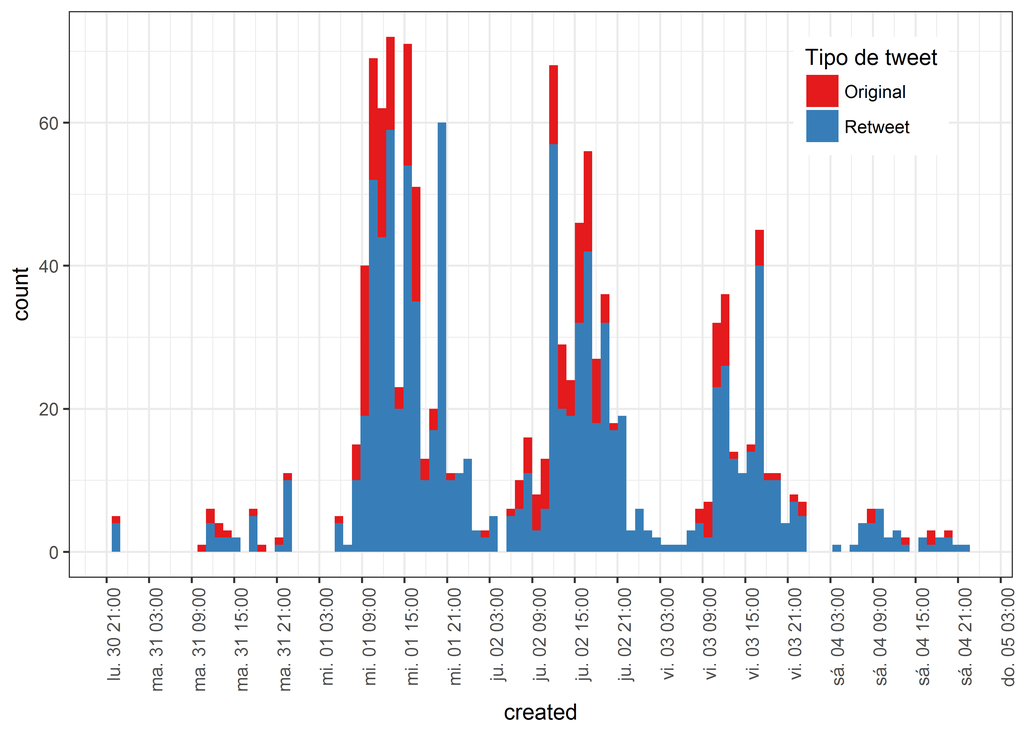

En este caso, el grueso de tuits generado se produjo el miércoles y jueves, e igual que en AEETMED la proporción de retuits parece aumentar por la tarde, como de hecho se puede comprobar en la siguiente figura.

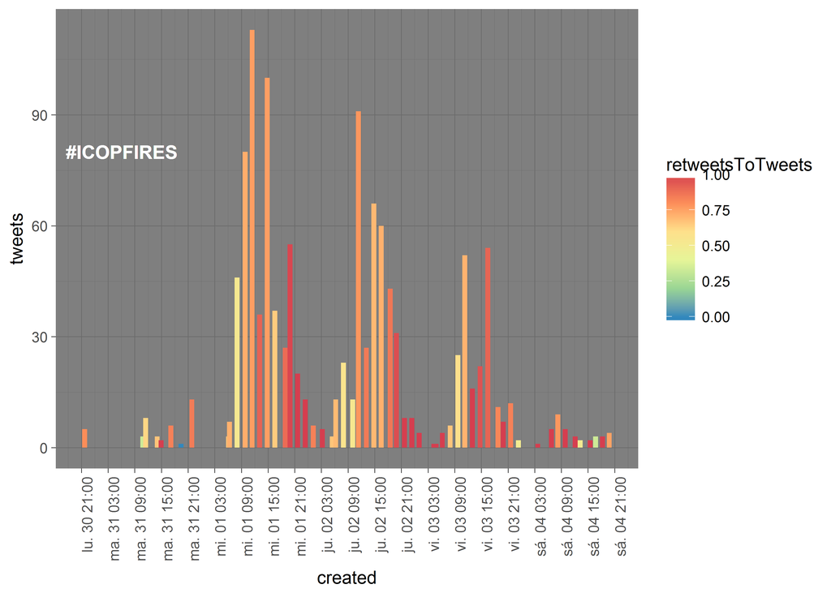

Por si alguno recuerda la entrada de ayer (y si no, la podéis encontrar [aquí](http://ecoforestalia.blogspot.com.es/2017/02/congresos-cientificos-y-twitter-i-un.html)), vemos que el ratio de retuits es bastante superior para este congreso de lo que fue para AEETMED, lo que indica que los tuits de iCOPFires tuvieron de media mayor difusión.

### Top 3 de tuits

De entre los 263 tuits originales generados (sin contar retuits), estos fueron los 3 más retuiteados, y curiosamente, también los 3 que más se marcaron como favoritos:

> Thanks to the almost 500 participants of 14th Int’l Wildland Fire Safety Summmit & Int’l Congress of Prescribed Fir https://t.co/crchKkPQ3Z

> — PauCostaF | [2017-02-02](https://twitter.com/PauCostaF/status/827165338735304704) | 40 retweets, 49 favorites.

> Crema prescrita #bomberscat #GRAF a Olesa de Montserrat en el marc del congrés internacional #iCOPFires @PauCostaF https://t.co/Q0j4s9aNku

> — bomberscat | [2017-02-03](https://twitter.com/bomberscat/status/827479500569059328) | 28 retweets, 44 favorites.

> Finaliza una intensa y apasionante jornada #iCOPFires para los 32 participantes de @AT_Brif ,mañana continuamos! https://t.co/HvjK1W8DMP

> — AT_Brif | [2017-02-01](https://twitter.com/AT_Brif/status/826869127482634240) | 25 retweets, 45 favorites.

#### Tuiteros más activos

Veamos quienes fueron los más activos de entre los 288 usuarios que tuitearon sobre el congreso utilizando la etiqueta oficial.

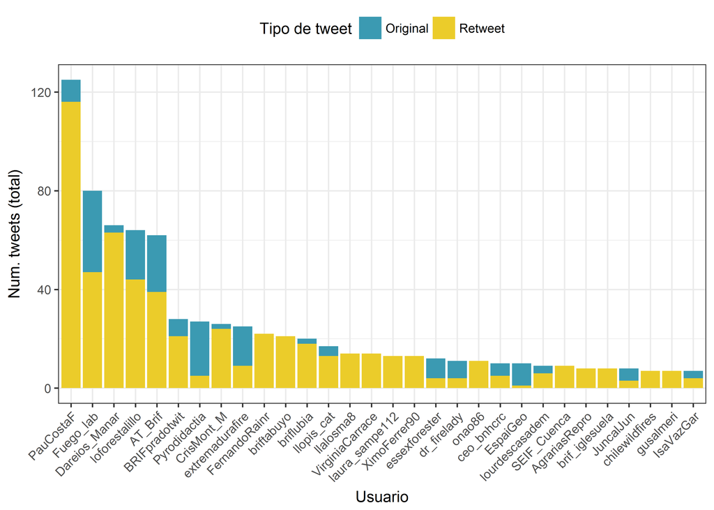

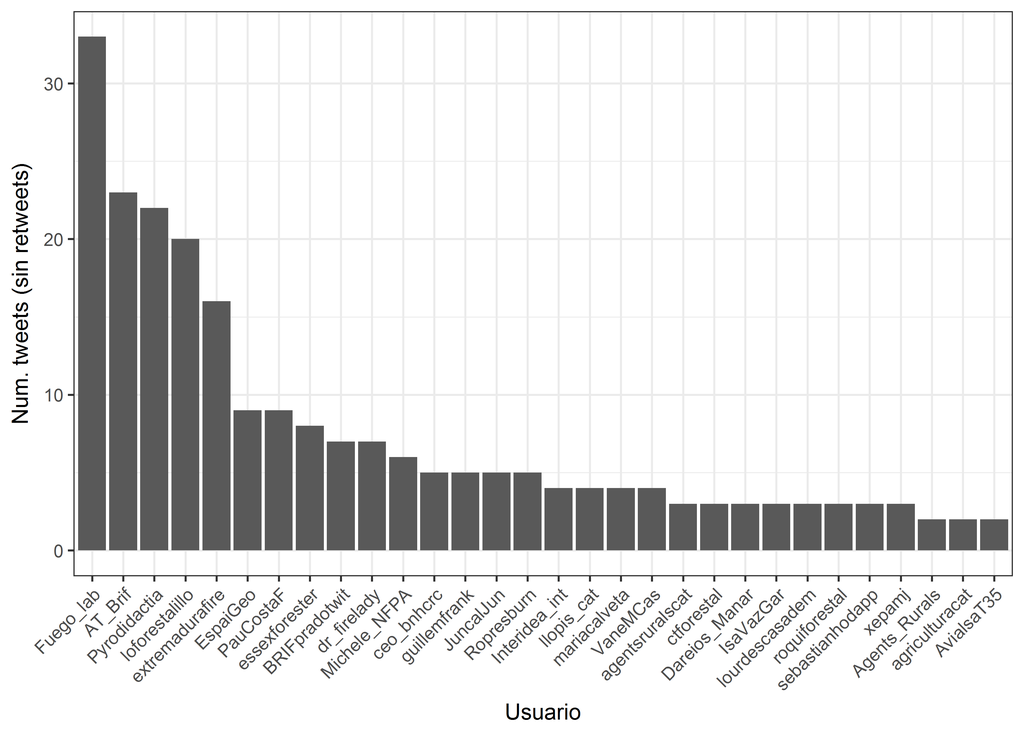

Si consideramos todos los tuits (originales y RTs), la [Fundación Pau Costa](https://twitter.com/PauCostaF) fue la cuenta más activa, con más de 120 tuits, seguidos por Fuego_lab, la cuenta de J. Madrigal, y la cuenta Dareios_Manar. Si excluimos los retuits, en cambio, Fuego_lab aparece como el más actuvo, seguido de lejos por la cuenta de la [Asociación de Trabajadores Brif](https://twitter.com/AT_Brif), Pyrodidactia y la cuenta de los GRAF, loforestalillo.

### Usuarios más populares

Pero no siempre tuitear mucho equivale a tener más repercusión. Éstas fueron las cuentas que recibieron, de media, más retuits por cada tuit que generaron. Una vez más destaca la Fundación Pau Costa, pero llama la atención a gran repercusión de otras cuentas como la de las [BRIF de Cuenca](https://twitter.com/BRIFpradotwit), la [As. de Trabajadores Brif](https://twitter.com/AT_Brif) o los [Agents Rurals de Catalunya](https://twitter.com/agentsruralscat). Esta última cuenta fue también la que más favoritos recibió de media.

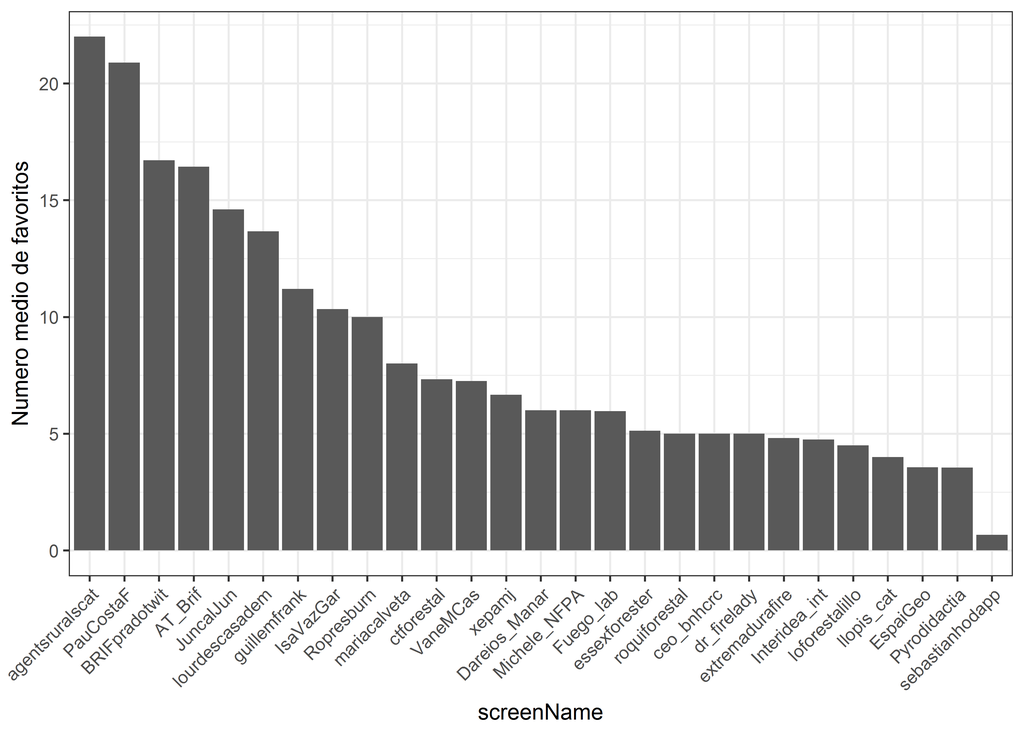

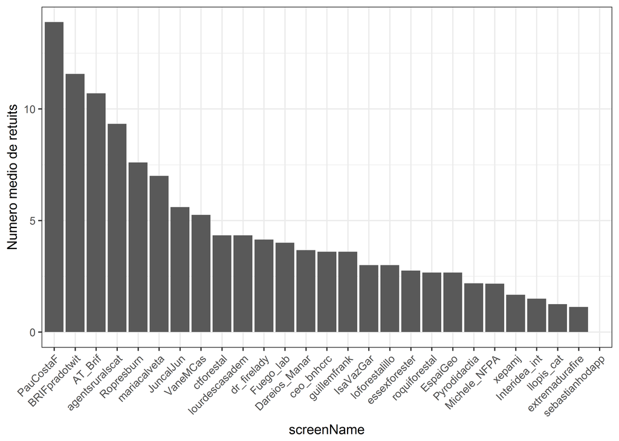

De hecho, si sumamos RTs y FAVs podemos calcular el impacto de una cuenta, y analizar si las cuentas con mayor impacto eran las que más tuitearon.

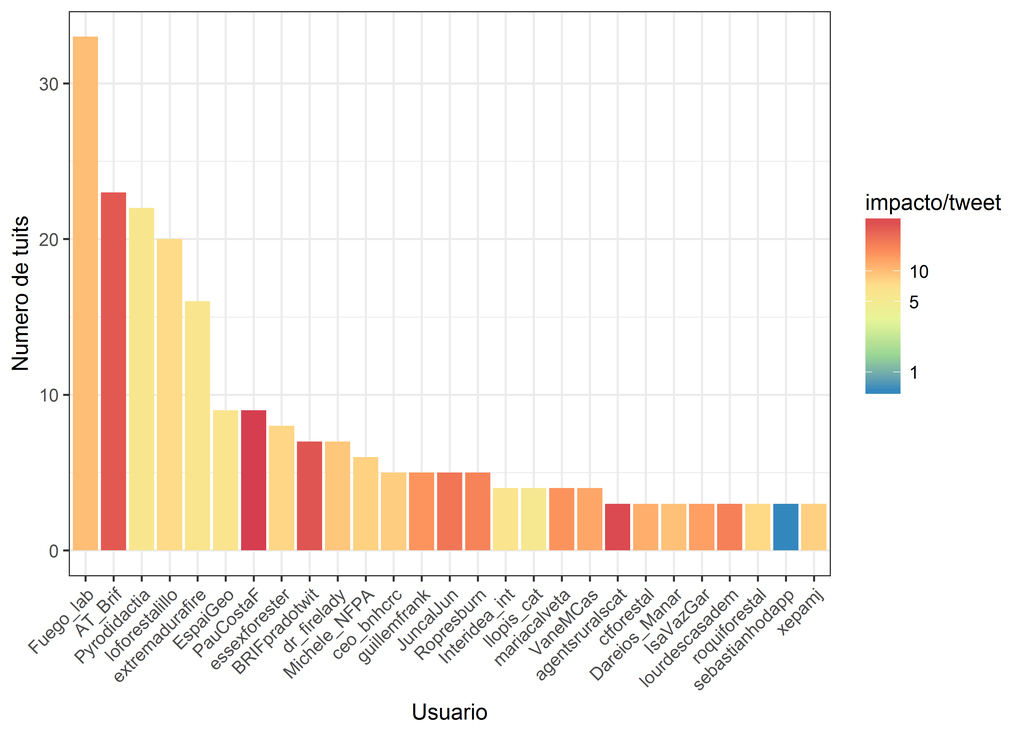

Parece que no es el caso, y algunas cuentas tienen un gran impacto sin necesidad de haber tuiteado demasiado, probablemente aquellas con mayor número de seguidores.

### Word cloud

Estas fueron las 50 palabras más frecuentes en los tweets etiquetados con #ICOPFIRES.

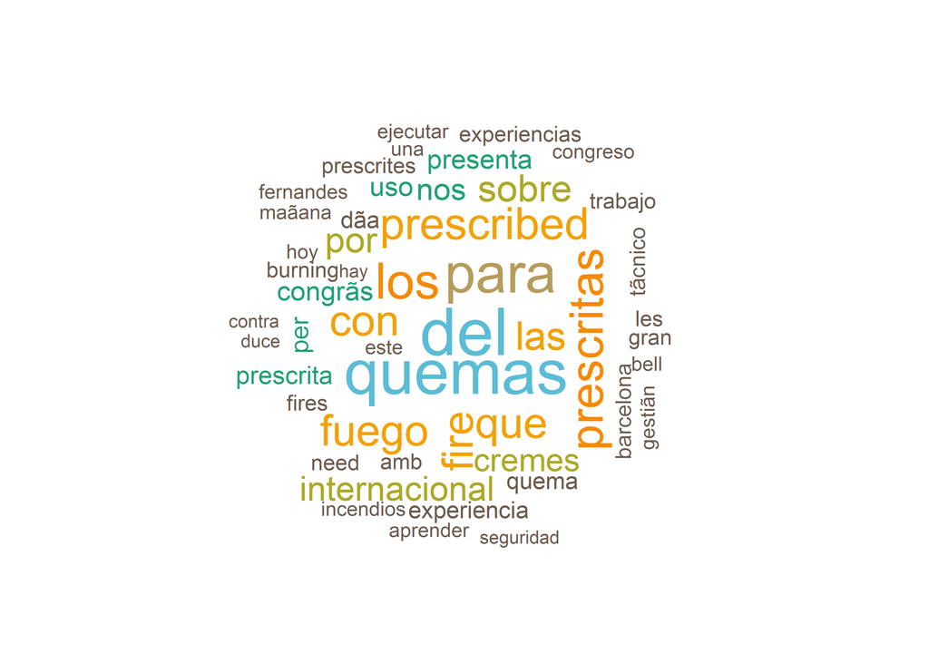

Pocas sorpresas, con “quemas”, “prescritas” y “fuego” como las más abundantes. Eso sí, llama la atención, en comparación con el word cloud de AEETMED, que en este caso dominan las palabras en español frente al inglés.

### Menciones: twitter como plataforma de conversación

La API de twitter nos permite rastrear la direccionalidad de las conversaciones, es decir, quien cita a quien en un tuit, y analizar por tanto qué usuarios han sido más mencionados, así como la dinámica de las menciones.

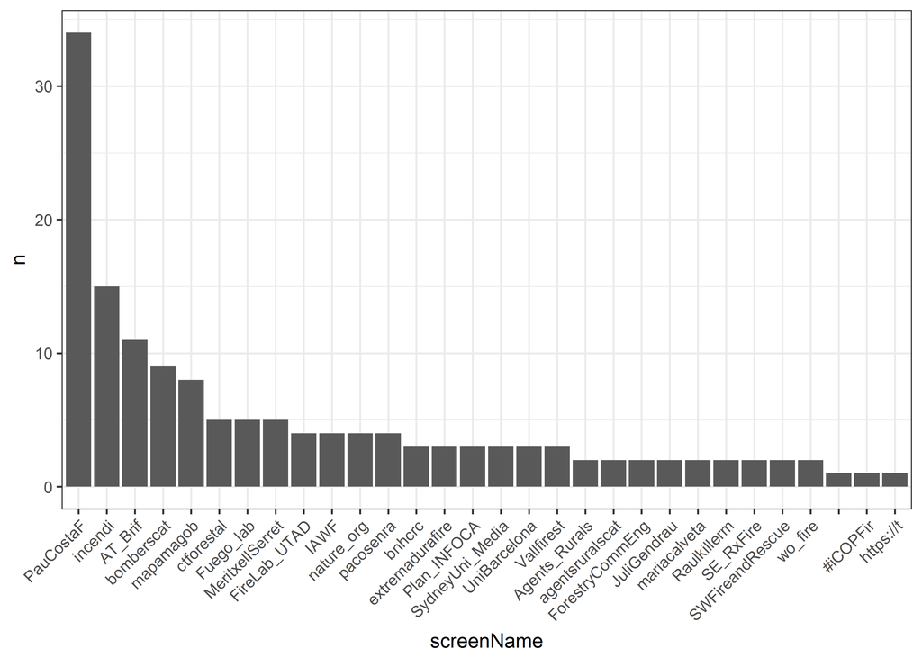

Domina claramente, una vez más, la Fundación Pau Costa, pero destaca el alto número de menciones que recibe Marc Castellnou ([@incendi](http://twitter.com/incendi)), a pesar de no haber tuiteado más de 4 veces durante el congreso.

### Twitter como red social

Como decía antes, podemos rastrear la direccionalidad de las menciones, lo que permite explorar las dinámicas de conversación mediante análisis de redes y representarlas en un grafo, utilizando los paquetes de R igraph y visNetwork. El resultado es un gráfico dinámico superchulo, pero que por desgracia parece no gustar a Blogger, por lo que os dejo la versión estática y os animo a pasaros por mi GitHub para ver el dinámico.

[interactive chart not shown]

Destaca, aunque no sorprende, el papel central de la F. Pau Costa, y un puñado de cuentas bien conectadas, ya que tanto reciben como emiten numerosas menciones (Fuego_lab, AT_Brif,[essexforester](http://twitter.com/essexforester...). Otras cuentas, en cambio, difundieron información a varias personas que sólo fueron mencionadas, pero no tuitearon (son las que aparecen en amarillo).

Mediante un análisis cluster podemos agrupar dicho gráfico de interacciones en grupos lo más homohenéos posible, y el resultado sería este (una vez más, para ver la versión dinámica tendréis que ir a [GitHub](https://github.com/ameztegui/Hashtag_Analysis)).

[interactive chart not shown]

Llama la atención que el algortimo (con los parámetros por defecto, no he tocado nada porque no domino la técnica de análisis) solo crea 7 grupos, de los que sólo 4 están realmente muy poblados, y los otros 3 son residuales, con solo unas pocas cuentas. Digo que sorprende porque en el análisis que publiqué ayer para el AEETMED el mismo algoritmo creó 23 grupos distintos. Para mí esto puede tener dos interpretaciones: una opción es que los asistentes a iCOPFires interactuan más entre sí, con lo que se diluirían las fornteras entre grupos. Pero también puede ser consecuencia de que en este congreso hay más actividad de cuentas institucionales (Pau Costa, CTFC, bombers de la Gencat…) o cuentas colectivas que agrupan a bastantes personas (las de las BRIF serían un buen ejemplo). Por tanto parece lógico que haya menos diversidad de interacciones. De hecho, si observamos los grupos maás poblados destaca que hay un usuario central muy bien conectado, que actúa de nexo de unión entre los miembros del grupo. Este papel lo jugarían, por un lado la cuenta de la F. Pau Costa, que recibe muchas menciones, y cuentas como Fuego_Lab o essexforester, que emiten muchas.

En cualquier caso, no me negaréis que es un gráfico que, además de ser chulo, tiene su miga. Os animo a que os busquéis y me digáis si os sorprende ver con quién habéis interactuado y en que grupo habéis caido!

Hasta aquí llega mi análisis de iCOPFires, pero antes de acabar quiero recalcar mi agradecimiento a aquellos que han generado el código original en el que me he basado, incluyendo [François Michonneau](https://github.com/fmichonneau), Joona Lehtomaki (jlehtoma en Twitter), y [Emily J. Rollinson](http://rollinsonecology.com/) (ejrollinson en Twitter), así como También he incorporado algunos elementos del análisis de redes que hizo [Keith H.Turner](http://twitter.com/kay_aych) para el [ISME2016](https://github.com/khturner/HashtagISME16). Recuerdo también que la entrada ha sido generada con rmarkdown, esta disponible en GitHub y tiene, como el código asociado, una [licencia CC0](https://creativecommons.org/choose/zero/?lang=es_ES).